# Latent trait analysis

Memo to Kyra and Mark

I was searching around for tools that do latent network space modeling more quickly, and found the lvm4net package (https://cran.r-project.org/web/packages/lvm4net/lvm4net.pdf). It’s more standalone than latentnet, which integrates nicely with statnet and ergm capabilities. But on the upside, it is *very* fast and turns out it has some really cool tools.

Firstly, it performs latent trait analysis (see https://arxiv.org/abs/1301.2167 and https://arxiv.org/abs/1905.02659, same author as lvm4net package). The basic idea in this case is that the concepts survey respondents selected are essentially categorical traits. There’s a lot of stats talk and monkey business behind that, but here’s the upshot…

#ignore this chunk, ut just loads and builds network object

```r
packs =c('tidyverse','purrr','data.table','statnet','latentnet','bipartite','lvm4net','ggthemes')
need = packs[!sapply(packs,function(x) suppressMessages(require(x,character.only=T)))]
sapply(need,function(x) suppressMessages(install.packages(x,,type= 'source')))
```

```
## named list()
```

```r
sapply(packs[need],function(x) suppressMessages(require(x,character.only=T)))
```

```
## named list()
```

```r
library(readxl)
orig = readxl::read_excel('Current Files/RawExcel/SLRSurvey_Full.xlsx')
orig$Q4[is.na(orig$Q4)]<-'Other'
#recode anything with fewer than 10 respondents as other
# see what wed recode
#as.data.table(table(orig$Q4))[order(-N),][N<10,]
orig$Q4[orig$Q4 %in% as.data.table(table(orig$Q4))[order(-N),][N<10,]$V1] <- 'Other'
orig$Q4[grepl('Other',orig$Q4)]<-'Other'
incidence_dt = fread('Current Files/Data/NewAdjacencyMatrix_ColumnRenames.csv')
incidence_mat = as.matrix(incidence_dt[,-c('ResponseId','ResponseId_number','DK')])
rownames(incidence_mat)<-incidence_dt$ResponseId
#drop isolates
incidence_mat = incidence_mat[rowSums(incidence_mat)!=0,]

#create network object
bip_net = as.network(incidence_mat,matrix.type = 'incidence',bipartite = T,directed = F,loops = F)
#code actor types
bip_net %v% 'Actor_Type' <- orig$Q4[match(network.vertex.names(bip_net),orig$ResponseId)]
#code concept types
concept_types = fread('Current Files/Data/CombinedNetwork/Combined_VectorTypes_NoNewOther.csv')
bip_net %v% 'Concept_Type' <- concept_types$Type[match(network.vertex.names(bip_net), concept_types$Vector)]
set.vertex.attribute(bip_net,'Concept_Type',value = 'Person',v = which(is.na(bip_net %v% 'Concept_Type')))
```

```r
#convert to incidence matrix
Y = as.sociomatrix(bip_net)
#run lta with 1 to 4 dimensions
dims = 1:4
d_list = lapply(dims,function(d) lta(Y,D = d))
names(d_list) <- paste0('D',dims)
print(sapply(d_list,function(x) x$BIC))
```

```
## D1.BIC (G-H Quadrature correction): D2.BIC (G-H Quadrature correction):
##                            24973.08                            25089.91
## D3.BIC (G-H Quadrature correction): D4.BIC (G-H Quadrature correction):
##                            25274.20                            25567.83
```

```r
mod = d_list[[2]]
#intercepts
print(mod$b)
```

```
##      Item 1   Item 2    Item 3    Item 4    Item 5    Item 6    Item 7
##  -0.6079623 -1.17326 -2.118291 -1.420244 -1.263208 -1.593201 -1.781927
##      Item 8    Item 9   Item 10   Item 11   Item 12 Item 13    Item 14
##  -0.9491013 -2.024019 -1.800906 -2.771894 -1.971079  -1.326 -0.6547904
##    Item 15   Item 16   Item 17   Item 18   Item 19    Item 20   Item 21
##  -2.525574 0.5285759 -1.405458 0.2570563 -2.704981 -0.8071988 -1.540851
##    Item 22    Item 23   Item 24   Item 25   Item 26   Item 27  Item 28
##  -3.451984 -0.2398439 -2.549695 -2.893362 -1.995142 -2.071494 -2.91327
##    Item 29   Item 30  Item 31  Item 32   Item 33   Item 34   Item 35   Item 36
##  -1.541856 -1.189708 -2.54216 -2.63369 -1.142783 -1.755312 -3.113139 -2.580074
##     Item 37   Item 38   Item 39   Item 40   Item 41
##  -0.4513727 -1.813944 -1.502075 -2.078346 -1.666914
```

```r
#slopes
print(mod$w)
```

```
##          Item 1    Item 2      Item 3     Item 4     Item 5    Item 6
## Dim 1 0.7111934 0.1753685  0.03929534 -0.1709222  0.2576013 0.2119609
## Dim 2 0.5975519 0.1356327 -0.05099844 -0.1463038 -0.4641126 0.2194652
##           Item 7      Item 8      Item 9     Item 10    Item 11    Item 12
## Dim 1 -0.8650583 -0.09968877 -0.12706162 -0.08629771 -0.1715884 -0.1071834
## Dim 2  0.3408345 -0.51640081  0.09693502 -0.20560410 -0.1792730  0.1388588
##         Item 13    Item 14    Item 15   Item 16     Item 17    Item 18
## Dim 1 0.1039268  0.0915397 -0.3394042 0.4802816  0.13914427 0.65547908
## Dim 2 0.3242692 -0.1135440 -0.1401711 0.3021263 -0.05213694 0.01285997
##           Item 19    Item 20    Item 21   Item 22    Item 23    Item 24
## Dim 1  0.12117146 -0.1425702  0.2027030 0.1733690 -1.0308515 0.07831387
## Dim 2 -0.03511943 -0.7628456 -0.4723434 0.1617564  0.7177032 0.14174553
##          Item 25    Item 26    Item 27    Item 28    Item 29    Item 30
## Dim 1  0.1572892 -0.1858276 -0.4061524 -0.1744009 -0.2621546 -0.2819015
## Dim 2 -0.0365158  0.1823853  0.1458160 -0.2144504  0.1216999 -0.1260243
##           Item 31     Item 32     Item 33   Item 34     Item 35     Item 36
## Dim 1 -0.06412118  0.04284185  0.09497792 0.3889611  0.12847200 -0.20846454
## Dim 2 -0.02142039 -0.27612325 -0.01977901 0.1868030 -0.08076387  0.08197261
##         Item 37    Item 38    Item 39    Item 40     Item 41
## Dim 1 0.5190403  0.3737274 0.18324015 -0.4085415 -0.21278062
## Dim 2 0.3815700 -0.4929660 0.06372281  0.2089627 -0.06096677
```

```r
unique( (bip_net %v% 'Actor_Type')[{bip_net %v% 'Concept_Type'}=='Person'])
```

```
##  [1] "Other"
##  [2] "Education/Consulting/Research"
##  [3] "No-profit organization/Non-governmental organization"
##  [4] "Local government (cities, counties)"
##  [5] "Environmental Group"
##  [6] "Trade/Business/Industry Group"
##  [7] "Regional government"
##  [8] "Environmental Special District (e.g. Park district, open space district)"
##  [9] "State government"
## [10] "Community-based organization"
## [11] "Water Infrastructure Special District (e.g. irrigation district)"
## [12] "Federal government"
```

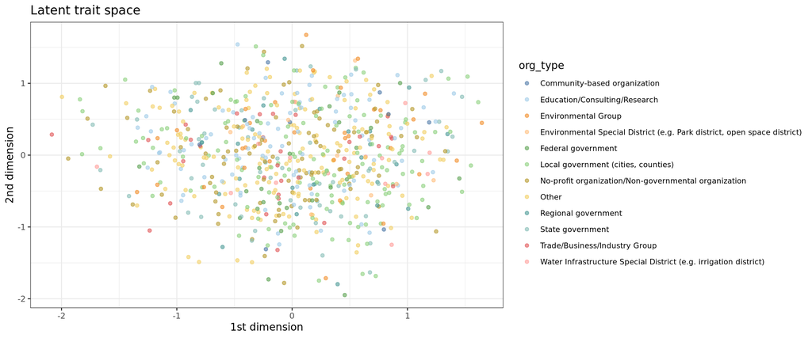

```r
trait_space = data.table(mod$mu)
trait_space$org_type = (bip_net %v% 'Actor_Type')[{bip_net %v% 'Concept_Type'}=='Person']
ggplot(trait_space) + geom_point(aes(x = V1,y = V2,col = org_type),pch = 19,alpha = 0.6) + xlab('1st dimension') +
  ylab("2nd dimension") + ggtitle('Latent trait space') + theme_bw() +
  scale_color_tableau(palette ='Tableau 20')+   scale_fill_tableau(palette ='Tableau 20')+
  theme(legend.text = element_text(size = 8))
```

Doesn’t seem to be a stark pattern at this point between actor type and location. But it’s tough to see acrsoss 10+ types anyways, so a simplied lens likely sheds more light.

The next thing that is feasible is a ‘mixture of latent trait analyzers’ (MLTA) model; real talk, I need to reread the arxiv paper again, because I can’t explain this very well. But the tl;dr is that it incorporates a group structure (like the clusters we’ve been discussing). To keep it simple, I’ll just use the 2-d model. The code also allows for different slopes by group (for logistic response function) but I turned that off.

```r
groups = 1:4
g_list = lapply(groups,function(g) mlta(X = Y,D = 2,G = g,wfix = T))
names(g_list) <- paste0('G', groups)
print(sapply(g_list,function(x) x$BIC))
```

```
## G1.BIC (G-H Quadrature correction): G2.BIC (G-H Quadrature correction):
##                            25088.74                            25199.86
## G3.BIC (G-H Quadrature correction): G4.BIC (G-H Quadrature correction):
##                            25311.82                            25467.14
```

What is not particularly promising here is that BIC scores prefer the G = 1 option… so not that fun. The G = 2 option is pretty close GOF wise, so we’ll continue with that. When there are multiple groups fit, there are cool results like the probability of membership in each group for each node:

```r
head(round(g_list[[2]]$z,2),20)
```

```
##       [,1] [,2]
##  [1,] 0.11 0.89
##  [2,] 0.89 0.11
##  [3,] 0.99 0.01
##  [4,] 0.02 0.98
##  [5,] 0.01 0.99
##  [6,] 0.81 0.19
##  [7,] 0.96 0.04
##  [8,] 1.00 0.00
##  [9,] 0.03 0.97
## [10,] 0.22 0.78
## [11,] 0.97 0.03
## [12,] 1.00 0.00
## [13,] 0.97 0.03
## [14,] 0.96 0.04
## [15,] 0.13 0.87
## [16,] 1.00 0.00
## [17,] 1.00 0.00
## [18,] 0.10 0.90
## [19,] 0.02 0.98
## [20,] 0.77 0.23
```

Since G = 2, 1 - p(g1) = p(g2). We can compare across org types:

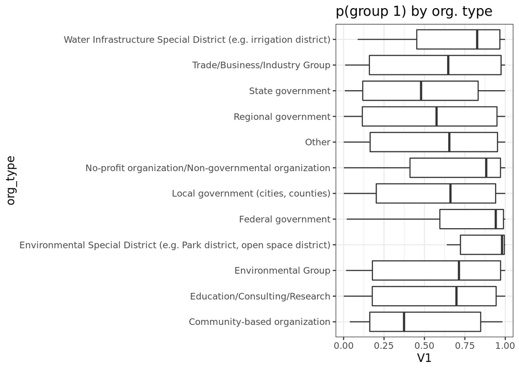

```r
p_org_dt = data.table(g_list[[2]]$z,org_type = trait_space$org_type)
ggplot(p_org_dt) + geom_boxplot(aes(y = V1,x = org_type)) + coord_flip() + theme_bw() + ggtitle('p(group 1) by org. type')
```

Just for kicks, here’s G = 3…

```r
p_3group = data.table(g_list[[3]]$z,org_type = trait_space$org_type)
p3 = melt(p_3group)
```

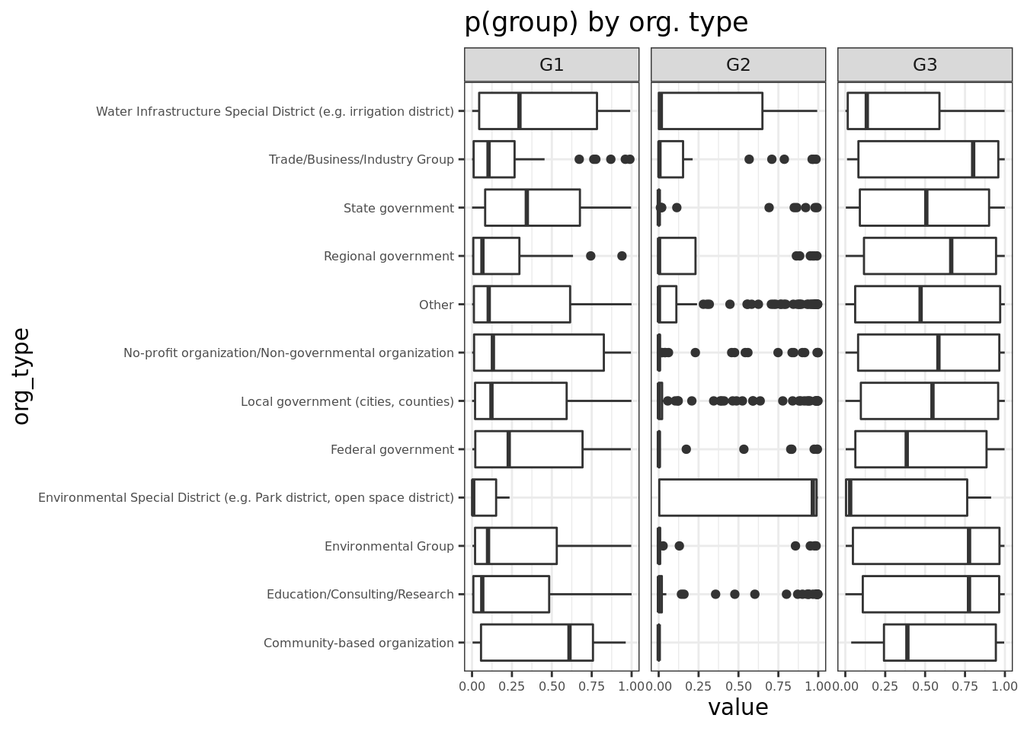

```r
p3$variable <- gsub('V','G',p3$variable)
ggplot(p3) + facet_wrap(~variable,ncol = 3) + geom_boxplot(aes(y = value,x = org_type)) +
  coord_flip() + theme_bw() + ggtitle('p(group) by org. type') + theme(axis.text = element_text(size = 6))
```

Instead of the latent trait analysis above, can also fit latent class analysis on the bipartite network. First example, 2 groups:

```r
m_lca = lca(X = Y,G = 2)
```

lca() outputs p-values for the conditional probability of observed a link between a concept and an actor if the concept is in group X.

```r
m_lca$p
```

```
##              p_g1      p_g2      p_g3      p_g4      p_g5      p_g6       p_g7
## Group 1 0.1977504 0.1937289 0.1094438 0.2308377 0.1462475 0.1150853 0.35140888
## Group 2 0.4909326 0.2695742 0.1060140 0.1713864 0.2889798 0.2128465 0.04020464
##              p_g8      p_g9     p_g10      p_g11     p_g12     p_g13     p_g14
## Group 1 0.2980489 0.1396450 0.1535548 0.09167076 0.1352919 0.1891018 0.2943823
## Group 2 0.2782402 0.1015164 0.1358578 0.03748949 0.1145083 0.2310125 0.3769896
##              p_g15     p_g16    p_g17     p_g18      p_g19     p_g20     p_g21
## Group 1 0.16818875 0.5281878 0.182000 0.4339872 0.04200131 0.3371272 0.1256717
## Group 2 0.01196058 0.6916344 0.209019 0.6510380 0.07818531 0.3117081 0.2274022
##               p_g22     p_g23      p_g24      p_g25     p_g26      p_g27
## Group 1 0.008755514 0.6758432 0.04404460 0.03723039 0.1458444 0.18320226
## Group 2 0.047910427 0.2871230 0.09396425 0.06437055 0.1044451 0.07015059
##              p_g28     p_g29     p_g30      p_g31      p_g32     p_g33
## Group 1 0.08798021 0.2387040 0.3144988 0.08970700 0.06671487 0.2219506
## Group 2 0.02782541 0.1361498 0.1801430 0.06108258 0.07024631 0.2566447
##              p_g34      p_g35      p_g36     p_g37      p_g38     p_g39
## Group 1 0.06354751 0.01926281 0.10881792 0.2716813 0.07561087 0.1472861
## Group 2 0.21792273 0.06005874 0.04485641 0.4845169 0.20677153 0.2093732
##              p_g40     p_g41
## Group 1 0.19350467 0.2258191
## Group 2 0.06273179 0.1133920
```

and lca() outputs p-values for the probability that each *actor* is part of group G:

```r
head(round(m_lca$z,2),10)
```

```
##       [,1] [,2]
##  [1,] 0.41 0.59
##  [2,] 0.71 0.29
##  [3,] 0.76 0.24
##  [4,] 0.12 0.88
##  [5,] 0.98 0.02
##  [6,] 0.98 0.02
##  [7,] 0.99 0.01
##  [8,] 0.95 0.05
##  [9,] 0.95 0.05
## [10,] 0.70 0.30
```

```r
lca_compare_G = lca(X = Y,G = 2:5)
lca_compare_G$BIC
```

```
## $`Model Selection`
## Model with lower BIC:
##                 "G=2"
##
## $`Table of BIC Results`
##      G=2      G=3      G=4      G=5
## 24940.69 25032.08 25171.07 25298.72
```

Again, G = 2 is best; G = 3 pretty close. What none of this accommodates is the incorporation of predictive covariates as inputs. But could be treated in relation to the *outputs* (e.g., association between covariate x and p-value of membership in one group or another).